# Data Mining Assignment3

Adnan Hajizada

March 22, 2016

Load librarires

```r
library(pls)
library(lars)
library(MASS)
library(robustbase)
library(quantreg)
```

1. Visualization

```r
suppressPackageStartupMessages(library(openintro))
data(countyComplete)

countyComplete$growth <- with(countyComplete, (pop2010 - pop2000) / pop2000 * 100)
include <- sample(nrow(countyComplete), size = 2000, replace = FALSE)
training <- countyComplete[include, ]
testing <- countyComplete[-include, ]
```

Let’s run an OLS regression to see which variables are worth looking at

```r
ols <- lm(growth ~ age_under_5 + age_under_18 + age_over_65 + female + white +
            black + native + asian + pac_isl + two_plus_races + hispanic +
            white_not_hispanic + no_move_in_one_plus_year + foreign_born +
            foreign_spoken_at_home + hs_grad + bachelors + veterans +
            mean_work_travel + housing_units + home_ownership + housing_multi_unit +
            households + persons_per_household + per_capita_income +
            median_household_income + poverty + firms + women_owned_firms + sales +
            sales_per_capita + fed_spending + density, data = training)
summary(ols)
```

```
##
## Call:
## lm(formula = growth ~ age_under_5 + age_under_18 + age_over_65 +
##     female + white + black + native + asian + pac_isl + two_plus_races +
##     hispanic + white_not_hispanic + no_move_in_one_plus_year +
##     foreign_born + foreign_spoken_at_home + hs_grad + bachelors +
##     veterans + mean_work_travel + housing_units + home_ownership +
##     housing_multi_unit + households + persons_per_household +
##     per_capita_income + median_household_income + poverty + firms +
##     women_owned_firms + sales + sales_per_capita + fed_spending +
##     density, data = training)
##
## Residuals:
##     Min      1Q  Median      3Q     Max
## -51.620  -5.460  -0.969   4.151  70.214
##
## Coefficients:
##                            Estimate Std. Error t value Pr(>|t|)
## (Intercept)              -2.760e+01  1.130e+02  -0.244 0.807068
## age_under_5               2.812e+00  1.104e+00   2.546 0.011140 *
## age_under_18             -7.828e-01  4.291e-01  -1.824 0.068657 .
## age_over_65              -1.767e-01  2.219e-01  -0.796 0.426103
## female                   -2.560e-03  2.953e-01  -0.009 0.993087
## white                     1.194e-01  2.002e-01   0.596 0.551266
## black                     2.154e-01  1.134e+00   0.190 0.849496
## native                    1.759e-01  1.114e+00   0.158 0.874615
## asian                    -4.934e-01  1.140e+00  -0.433 0.665344
## pac_isl                   2.446e+00  1.725e+00   1.418 0.156708
## two_plus_races            2.206e-01  1.088e+00   0.203 0.839459
## hispanic                  1.569e-01  1.011e+00   0.155 0.876692
## white_not_hispanic        1.577e-01  1.047e+00   0.151 0.880367
## no_move_in_one_plus_year -4.884e-01  1.421e-01  -3.438 0.000629 ***
## foreign_born              4.721e-01  1.843e-01   2.562 0.010669 *
## foreign_spoken_at_home   -7.379e-02  1.458e-01  -0.506 0.613019
## hs_grad                   7.790e-03  1.392e-01   0.056 0.955386
## bachelors                 5.828e-01  1.215e-01   4.798 2.04e-06 ***
## veterans                  1.104e-04  7.335e-05   1.505 0.132836
## mean_work_travel          6.985e-01  1.277e-01   5.470 6.71e-08 ***
## housing_units             1.293e-04  4.902e-05   2.637 0.008580 **
## home_ownership            7.020e-02  1.274e-01   0.551 0.581823
## housing_multi_unit       -3.114e-01  1.008e-01  -3.090 0.002095 **
## households               -7.629e-05  6.020e-05  -1.267 0.205552
## persons_per_household     1.020e+01  3.444e+00   2.962 0.003176 **
## per_capita_income        -6.558e-04  2.930e-04  -2.238 0.025588 *
## median_household_income   2.624e-04  1.540e-04   1.704 0.088922 .
## poverty                  -9.224e-02  1.782e-01  -0.518 0.604927
## firms                     4.610e-05  6.156e-05   0.749 0.454199
## women_owned_firms        -8.475e-02  7.890e-02  -1.074 0.283183
## sales                    -2.034e-06  4.887e-07  -4.161 3.65e-05 ***
## sales_per_capita          3.394e-04  9.389e-05   3.615 0.000327 ***
## fed_spending             -8.099e-07  2.391e-07  -3.388 0.000753 ***
## density                   5.220e-05  4.860e-04   0.107 0.914503
## ---
## Signif. codes:  0 '***' 0.001 '**' 0.01 '*' 0.05 '.' 0.1 ' ' 1
##
## Residual standard error: 10.41 on 581 degrees of freedom
##   (1385 observations deleted due to missingness)
## Multiple R-squared:  0.4303, Adjusted R-squared:  0.398
## F-statistic:  13.3 on 33 and 581 DF,  p-value: < 2.2e-16
```

I am going to choose the bachelor as an importnat factor that can predict the population growth. The amount of people with bachelor degrees in a given county can give us information about the general economic growth that is going on there, more skilled jobs are opening up, more people are moving in and hence larger population growth. This is the initial scatter plot with just bachelors and growth

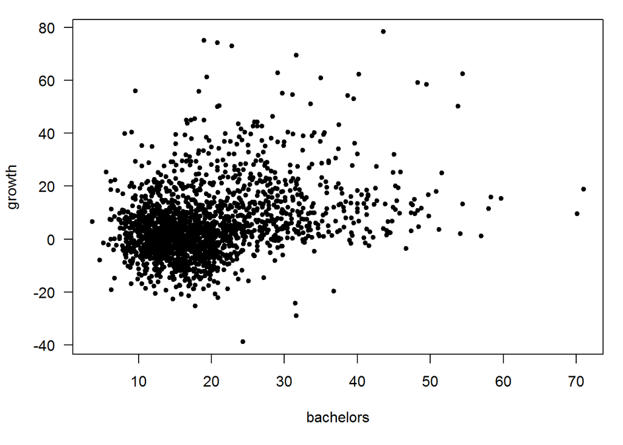

```r
par(mar = c(5,4,1,1) + .1, pch = 20, las = 1)
with(training, plot(x = bachelors, y = growth))
```

Now We will add sales per capita in the form of four colors that represent the quantiles. (from lo to hi) Hypothesis: Higher amount of sales per capita signals bigger economic growth and can predict bigger population growth Also, I am adding 4 symbols for the plots that will show us the amount of families that has not moved within one year. Hypothesis: Greater movement is correlated with bigger growth.

```r
summary(training$sales_per_capita)
```

```
##    Min. 1st Qu.  Median    Mean 3rd Qu.    Max.    NA's
##       0    7145    9840   10450   13100   76510      27
```

```r
spc_cut_3 <- cut(training$sales_per_capita, c(0,6843,10290,13120,76510), labels = c(1:4) )

summary(training$no_move_in_one_plus_year)
```

```
##    Min. 1st Qu.  Median    Mean 3rd Qu.    Max.
##   51.60   83.30   86.40   85.85   89.00   98.20
```

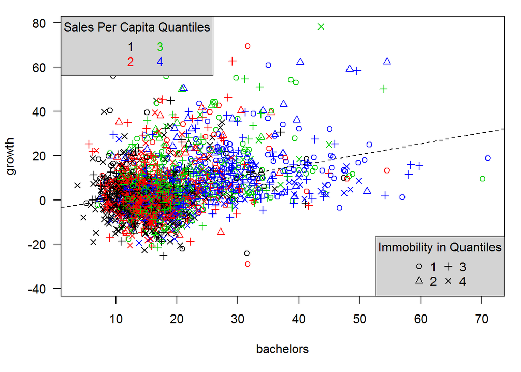

```r
training$nmiopy_cut_4 <- cut(training$no_move_in_one_plus_year, c(51,83,85,88,100), labels = c(1:4) )
par(mar = c(5,4,1,1) + .1, pch = 20, las = 1)
with(training, plot(x = bachelors, y = growth, col = spc_cut_3, pch = as.numeric(nmiopy_cut_4)))
legend("topleft", legend = 1:4, text.col = 1:4, title = "Sales Per Capita Quantiles",
       bg = "lightgray", box.lwd = 0, ncol = 2)
legend("bottomright", legend = 1:4, pch = 1:4, title = "Immobility in Quantiles",
       bg = "lightgray", box.lwd = 0, ncol=2)
abline(lm(growth ~ bachelors, data = training), lty = "dashed")
```

We can see that the counties with high sales per capita are associated with higher growth. And the black dots which are the counties with the lowest sales per capita are associated with lower growth. The circle symbol represents the counties with a large number of families who have moved within one year. As you can see among the Blue (large sales per capita) plots and towards the right of the graph we can find numerous plots with highly mobile counties. Sales per capita can laso be an indicator of the number of houses and appartments being bought and sold.

2 Prediction with Linear Models

```r
ols_training <- lm(growth ~ no_move_in_one_plus_year + bachelors + mean_work_travel +
                     housing_units + households + sales_per_capita, data = training)
summary(ols_training)
```

```
##
## Call:
## lm(formula = growth ~ no_move_in_one_plus_year + bachelors +
##     mean_work_travel + housing_units + households + sales_per_capita,
##     data = training)
##
## Residuals:
##     Min      1Q  Median      3Q     Max
## -56.975  -6.168  -1.396   4.415  66.450
##
## Coefficients:
##                            Estimate Std. Error t value Pr(>|t|)
## (Intercept)               3.244e+01  4.899e+00   6.622 4.56e-11 ***
## no_move_in_one_plus_year -7.023e-01  5.542e-02 -12.673  < 2e-16 ***
## bachelors                 4.033e-01  3.259e-02  12.374  < 2e-16 ***
## mean_work_travel          1.035e+00  4.736e-02  21.851  < 2e-16 ***
## housing_units             1.605e-04  3.493e-05   4.596 4.58e-06 ***
## households               -1.840e-04  3.866e-05  -4.760 2.07e-06 ***
## sales_per_capita          1.883e-04  5.272e-05   3.573 0.000362 ***
## ---
## Signif. codes:  0 '***' 0.001 '**' 0.01 '*' 0.05 '.' 0.1 ' ' 1
##
## Residual standard error: 10.62 on 1965 degrees of freedom
##   (28 observations deleted due to missingness)
## Multiple R-squared:  0.3144, Adjusted R-squared:  0.3123
## F-statistic: 150.2 on 6 and 1965 DF,  p-value: < 2.2e-16
```

```r
yhat_popgrowth <- predict(ols_training, newdata = testing)
"OLS model SSE"
```

```
## [1] "OLS model SSE"
```

```r
(SSE_popgrowth <- mean((testing$growth - yhat_popgrowth) ^ 2, na.rm = TRUE))
```

```
## [1] 140.2946
```

3 Prediction with Alternative Linear Models. When working the Lars model, lasso wouldn’t compute so i deciede to test th RQ model instead.

```r
PCR <- pcr(growth ~ no_move_in_one_plus_year + bachelors + mean_work_travel +
              housing_units + households + sales_per_capita, data = training, validation = "LOO")
summary(PCR)
```

```
## Data:    X dimension: 1972 6
##  Y dimension: 1972 1
## Fit method: svdpc
## Number of components considered: 6
##
## VALIDATION: RMSEP
## Cross-validated using 1972 leave-one-out segments.
##        (Intercept)  1 comps  2 comps  3 comps  4 comps  5 comps  6 comps
## CV           12.81    12.78    12.67    12.56    12.03    11.48    10.74
## adjCV        12.81    12.78    12.67    12.56    12.03    11.48    10.74
##
## TRAINING: % variance explained
##         1 comps  2 comps  3 comps  4 comps  5 comps  6 comps
## X         99.84   99.927  100.000   100.00   100.00   100.00
## growth     1.86    3.719    4.623    12.32    21.13    31.44
```

```r
yhat_pcr <- predict(PCR, newdata = testing)

"PCR Model SSE:"
```

```
## [1] "PCR Model SSE:"
```

```r
(SSE_pcr <- mean((testing$growth - yhat_pcr) ^ 2, na.rm = TRUE))
```

```
## [1] 169.2916
```

```r
growth_rq <- rq(growth ~ no_move_in_one_plus_year + bachelors + mean_work_travel +
             housing_units + households + sales_per_capita, data = training)
summary(growth_rq)
```

```
##
## Call: rq(formula = growth ~ no_move_in_one_plus_year + bachelors +
##     mean_work_travel + housing_units + households + sales_per_capita,
##     data = training)
##
## tau: [1] 0.5
##
## Coefficients:
##                          Value     Std. Error t value   Pr(>|t|)
## (Intercept)               37.21049   4.69940    7.91814   0.00000
## no_move_in_one_plus_year  -0.74882   0.05111  -14.65129   0.00000
## bachelors                  0.34867   0.03830    9.10357   0.00000
## mean_work_travel           0.96831   0.04206   23.02112   0.00000
## housing_units              0.00023   0.00004    5.54170   0.00000
## households                -0.00026   0.00005   -5.28515   0.00000
## sales_per_capita           0.00022   0.00004    5.09115   0.00000
```

```r
yhat_rq <- predict(growth_rq, newdata = testing)
"RQ Model SSE"
```

```
## [1] "RQ Model SSE"
```

```r
(SSE_rq <- mean((testing$growth - yhat_rq) ^ 2, na.rm = TRUE))
```

```
## [1] 141.0946
```

In our case it looks like the mean squared of OLS model is the smallest